# Lifecycle and mental health

Ishani Makwana, Henry Hirsch and Ei Tanaka

2023-04-15

```r
# Import Libraries
rm(list=ls())
library(readr)
library(ggplot2)
library(tidyr)
library(corrplot)
library(ezids)
library(car)
```

```r
url <- 'https://raw.githubusercontent.com/eitanaka/DATS6101_Final_Project_Team2/main/data_set/geo_socio_health_df.csv'
master_df<- read_csv(url)
```

## Introcuction

In project 1, we investigated how health risk behaviors are associated with health outcomes and health status. Now we are trying to examine whether there is any significant influence on mental health due to lifestyle, socio-economic factors, and covid-19 in the United States. Census tracts will be used in calculating and analyzing all the different datasets. This research will help us in identifying and expecting what factors have significantly impacted mental health and well-being in the United States in 2020.

### Initial SMART Question

2. How can we expect predictors to contribute to increased depression and poor mental health?

## EDA

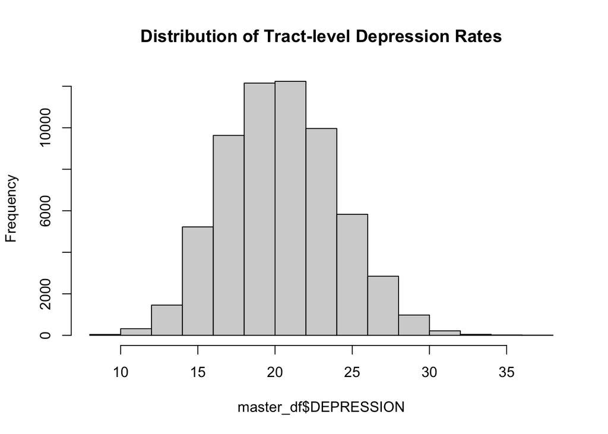

```r
# checking normality of dependent variables
colnames(master_df)[colnames(master_df) == "MT_Never Married"] <- "MT_never_married"
colnames(master_df)[colnames(master_df) == "MT_Now married"] <- "MT_now_married"
colnames(master_df)[colnames(master_df) == "Total Population"] <- "total_population"
colnames(master_df)[colnames(master_df) == "EA_Less than high school graduate"] <- "EA_Less_than_high_school_graduate"
colnames(master_df)[colnames(master_df) == "EA_High school graduate"] <- "EA_High_school_graduate"
colnames(master_df)[colnames(master_df) == "EA_college or associate's degree"] <- "EA_college_or_associates_degree"
colnames(master_df)[colnames(master_df) == "EA_Bachelor's degree"] <- "EA_Bachelors_degree"
colnames(master_df)[colnames(master_df) == "EA_Graduate or professional degree"] <- "EA_Graduate_or_professional_degree"

# histograms
dep_hist <- hist(master_df$DEPRESSION, main = "Distribution of Tract-level Depression Rates")
```

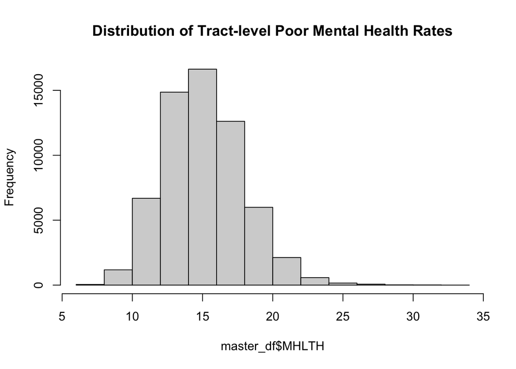

```r
mhlth_hist <- hist(master_df$MHLTH, main = "Distribution of Tract-level Poor Mental Health Rates")
```

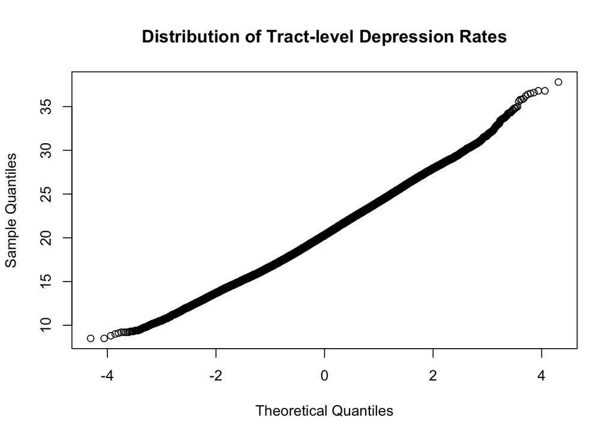

```r
dep_hist
mhlth_hist

# qqplots
dep_qq <- qqnorm(master_df$DEPRESSION, main = "Distribution of Tract-level Depression Rates")
```

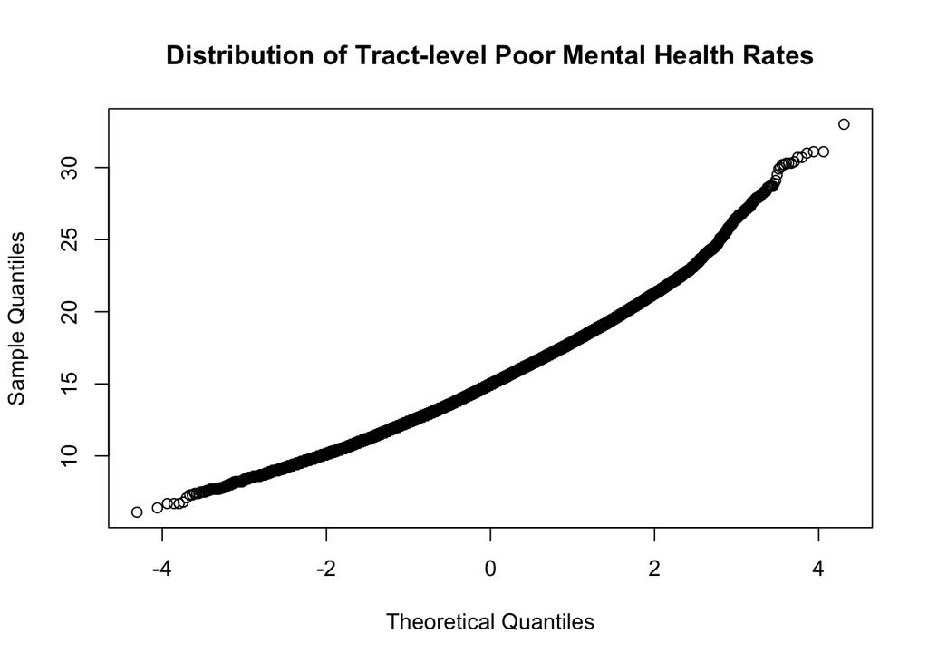

```r
mhlth_qq <- qqnorm(master_df$MHLTH, main = "Distribution of Tract-level Poor Mental Health Rates")
```

```r
dep_qq
mhlth_qq

# create data frame of only numeric values
cols_to_remove <- c("...1", "CountyFIPS", "GEOID", "StateAbbr", "CountyName", "MT_Total", "EA_Total", "total_population", "CT_Total", "ES_Total", "LAND_AREA")
num_df <- master_df[ , !names(master_df) %in% cols_to_remove]

# hist_list <- lapply(names(num_df), function(col) {
#   ggplot(num_df, aes_string(x = col)) +
#     geom_histogram() +
#     ggtitle(col)
# })
# hist_list
```

### Basic EDA

#### Handle Null Values

```r
master_df <- na.omit(master_df)
colSums(is.na(master_df[6:length(master_df)]))
```

[output not shown]

## Data Structure

```r
str(master_df)
```

[output not shown]

## Summary Statictics

```r
summary(master_df)
```

[output not shown]

### Correlations

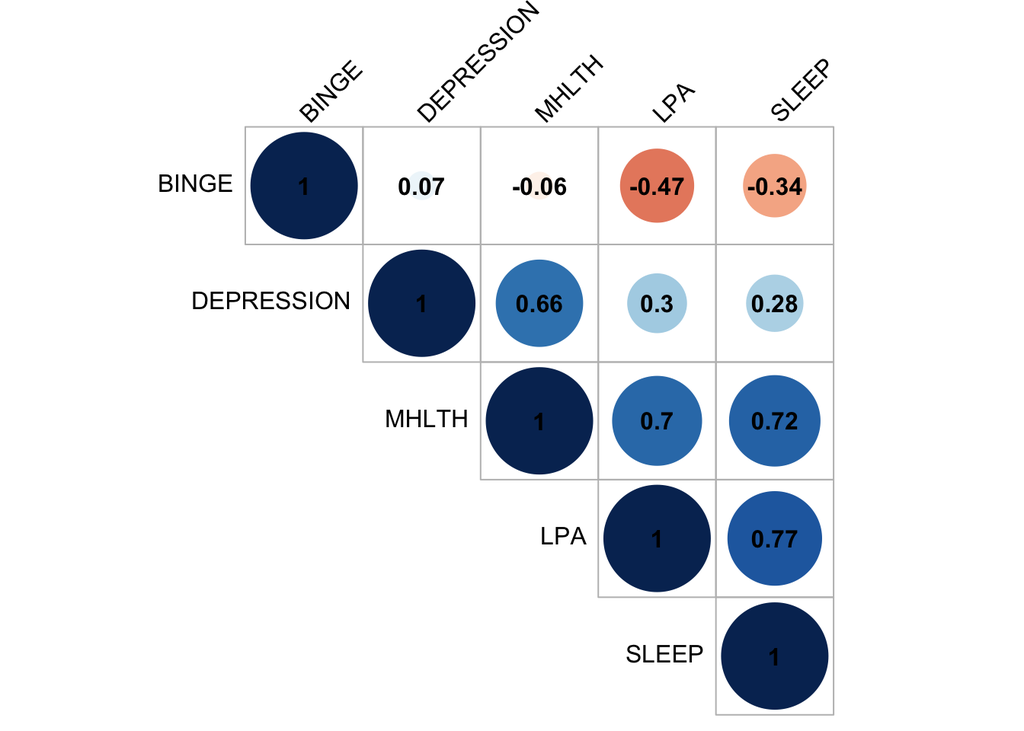

```r
cor_matrix <- cor(master_df[,6:length(master_df)])

# Create 6 subset for cor_matrix or cor_heatmap
dep_mth_df <- subset(master_df, select = "DEPRESSION")
dep_mth_df <- cbind(dep_mth_df, master_df[,9])

# Data frame containing depression, mhlth, health risk behaviors
dep_mth_hrb <- dep_mth_df
dep_mth_hrb["BINGE"] <- master_df[,6]
dep_mth_hrb["LPA"] <- master_df[,8]
dep_mth_hrb["SLEEP"] <- master_df[,10]

# Data frame containing depression, mhlth, MT
dep_mth_mt <- cbind(dep_mth_df, master_df[12:16])
# Data frame containing depression, mhlth, EA, MI, Pop
dep_mth_ea_mi_pop <- cbind(dep_mth_df, master_df[18:24])
# Data Frame containing depression, mhlth, MI, Pop, CT
dep_mth_ct <- cbind(dep_mth_df, master_df[26:34])
# Data Frame containing depression, mhlth, ES
dep_mth_es <-cbind(dep_mth_df, master_df[36:41])
# Data Frame containing depression, mhlth, others
dep_mth_geo <- cbind(dep_mth_df, master_df[42:length(master_df)])

# A set of cormatrix
cor_matrix_HRB <- cor(dep_mth_hrb)
cor_matrix_MT_EA <- cor(dep_mth_mt)
cor_matrix_EA_MI_POP <- cor(dep_mth_ea_mi_pop)
cor_matrix_CT <- cor(dep_mth_ct)
cor_matrix_ES <- cor(dep_mth_es)
cor_matrix_GEO <- cor(dep_mth_geo)

# Plot
corrplot(cor_matrix_HRB, method = "circle", type = "upper", order = "hclust", addCoef.col = "black", tl.col = "black", tl.srt = 45, cl.pos = "n")
```

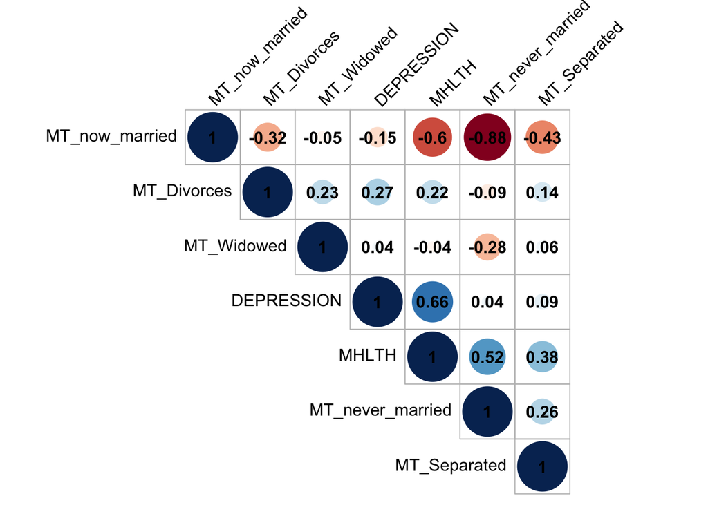

```r
corrplot(cor_matrix_MT_EA, method = "circle", type = "upper", order = "hclust", addCoef.col = "black", tl.col = "black", tl.srt = 45, cl.pos = "n")
```

[figure not shown]

```r
corrplot(cor_matrix_EA_MI_POP, method = "circle", type = "upper", order = "hclust", addCoef.col = "black", tl.col = "black", tl.srt = 45, cl.pos = "n")
```

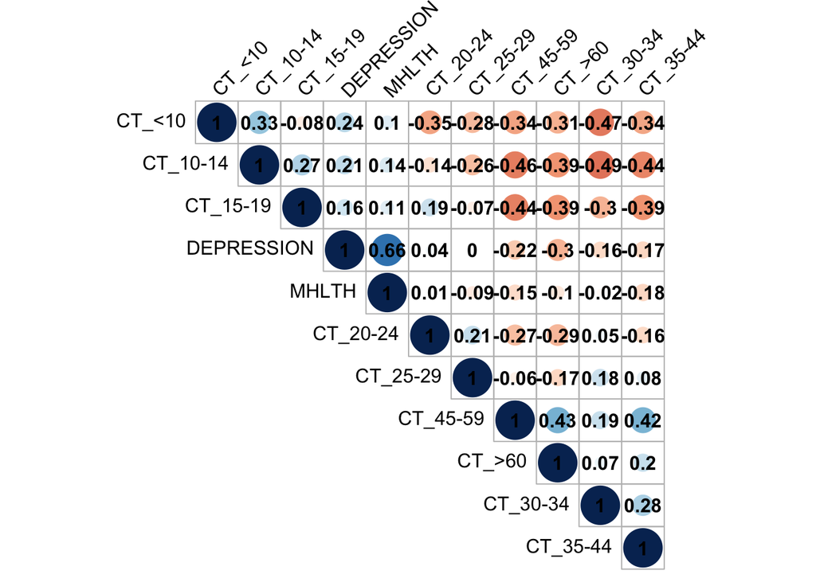

```r
corrplot(cor_matrix_CT, method = "circle", type = "upper", order = "hclust", addCoef.col = "black", tl.col = "black", tl.srt = 45, cl.pos = "n")
```

[figure not shown]

```r
corrplot(cor_matrix_ES, method = "circle", type = "upper", order = "hclust", addCoef.col = "black", tl.col = "black", tl.srt = 45, cl.pos = "n")
```

[figure not shown]

```r
corrplot(cor_matrix_GEO, method = "circle", type = "upper", order = "hclust", addCoef.col = "black", tl.col = "black", tl.srt = 45, cl.pos = "n")
```

#### Variable Selection

```r
cols_names_depression <- names(which(abs(cor_matrix[2, ]) >= 0.3))
depression_cor_df <- master_df[, c("DEPRESSION", "LPA", "EA_High_school_graduate", "EA_Bachelors_degree", "EA_Graduate_or_professional_degree", "MI_Estimate", "URBANIZED_AREA_POP_CEN_2010", "pct_URBANIZED_AREA_POP_CEN_2010")]

cols_mhlth <- names(which(abs(cor_matrix[4, ]) >= 0.3))
mhlth_cor_df <- master_df[,c("MHLTH", "LPA", "SLEEP", "MT_never_married", "MT_now_married", "MT_Separated", "EA_Less_than_high_school_graduate", "EA_High_school_graduate", "EA_Bachelors_degree", "EA_Graduate_or_professional_degree", "MI_Estimate", "ES_Civilian_labor_force_employed", "ES_Civilian_labor_force_unemployed")]
```

### VIF Test for Multicollinearity

```r
calculate_VIF <- function(data, target_col) {
  X <- data[, !colnames(data) %in% target_col]
  vif <- data.frame(
    Feature = colnames(X),
    VIF = apply(X, 2, function(x) vif(lm(x ~ ., data=X)))
  )
  return(vif)
}

depression_VIF <- calculate_VIF(depression_cor_df, "DEPRESSION")
mhlth_VIF <- calculate_VIF(mhlth_cor_df, "MHLTH")

depression_VIF
mhlth_VIF
```

[output not shown]

## Model Building

### Multiple Linear regression vs. Regression Tree (we must delete this part in the summary paper)

Multiple linear regression and regression tree are two different types of models used for predicting the value of a dependent variable based on one or more independent variables. The main differences between the two models are:

- Model complexity: Multiple linear regression models assume a linear relationship between the dependent and independent variables, and involve estimating a set of coefficients that describe the relationship. In contrast, regression trees involve recursively partitioning the data into subsets based on the independent variables, and fitting a separate model to each subset. This makes regression trees more flexible than linear regression models, but also more complex and harder to interpret.
- Variable selection: Multiple linear regression models typically involve selecting a subset of independent variables that are most predictive of the dependent variable. This is often done using methods such as stepwise regression or regularization. In contrast, regression trees can use all available independent variables in the model, and automatically select the most important variables based on the tree structure.
- Interpretability: Multiple linear regression models provide interpretable coefficients that describe the relationship between the dependent and independent variables. In contrast, regression trees can be harder to interpret, as they involve recursively partitioning the data into subsets based on the independent variables. However, decision trees can be visualized and interpreted to gain insights into the relationships between the independent variables and the dependent variable.
- Performance: The performance of multiple linear regression models depends on the linearity and homoscedasticity assumptions, and may suffer from overfitting or underfitting if the model is too simple or too complex. In contrast, regression trees are more flexible and can capture nonlinear relationships between the dependent and independent variables. However, they may also suffer from overfitting if the tree is too deep or complex.

Overall, multiple linear regression and regression tree are both useful models for predicting the value of a dependent variable based on one or more independent variables. The choice between the two models depends on the specific problem and the data available.

### Multiple Linear Regression

```r
# multiple linear regression model for depression
depression_model <- lm(DEPRESSION ~ LPA + EA_High_school_graduate + EA_Bachelors_degree + EA_Graduate_or_professional_degree + MI_Estimate + URBANIZED_AREA_POP_CEN_2010 + pct_URBANIZED_AREA_POP_CEN_2010, data = depression_cor_df)

# multiple linear regression model for poor mental health
mhlth_model <- lm(MHLTH ~ LPA + SLEEP + MT_never_married + MT_now_married + MT_Separated + EA_Less_than_high_school_graduate + EA_High_school_graduate + EA_Bachelors_degree + EA_Graduate_or_professional_degree + MI_Estimate + ES_Civilian_labor_force_employed + ES_Civilian_labor_force_unemployed, data = mhlth_cor_df)
```

#### Multiple linear regression model Evaluation

(From Textbook) 5. Model Evaluation - R-squared: R-squared is a measure of the proportion of variation in the dependent variable that is explained by the independent variables in the model. Higher R-squared values indicate a better fit of the model to the data. However, R-squared alone may not provide a complete picture of the model’s performance. - Significance of coefficient - Residual analysis: Residual analysis involves examining the residuals (the differences between the observed and predicted values of the dependent variable) to assess the fit of the model. A good model should have residuals that are normally distributed with a mean of 0 and constant variance (homoscedasticity). Residual plots can help identify outliers and non-linear relationships in the data. - F-test: The F-test is a statistical test that compares the fit of the full model (with all independent variables) to a reduced model (with fewer independent variables). A significant F-test indicates that the full model provides a better fit to the data than the reduced model. - if comparing models: anova - if comparing models of different # of variables: use other criteria such as Adj R2, BIC, AIC, Marlow’s Cp. - Cross-validation: Cross-validation involves splitting the data into training and testing sets to evaluate the performance of the model on new data. Cross-validation can help assess the generalizability of the model to new data and identify potential issues with overfitting. 6 .Model selection: feature selection, interaction terms, etc. Steps 5 and 6 might repeat to many times in search of a good model. Other times might need to restart from 2 to try out different model structures.

```r
summary(depression_model)
summary(mhlth_model)
```

[output not shown]

##### No Auto-colinearity (independence)

The Durbin-Watson test is a statistical test that evaluates whether the residuals (errors) in a regression model are independent of each other. This will output the Durbin-Watson test statistic, the degrees of freedom, and the p-value. The null hypothesis of the Durbin-Watson test is that there is no autocorrelation (independence) in the residuals. A p-value less than 0.05 suggests evidence of autocorrelation, while a p-value greater than 0.05 suggests no evidence of autocorrelation.

```r
# The Durbin-Watson test
library(lmtest)
depression_dwtest <- dwtest(depression_model)
mhlth_dwtest <- dwtest(mhlth_model)

depression_dwtest
mhlth_dwtest
```

[output not shown]

##### Homoscedasticity

Breusch-Pagan test: The Breusch-Pagan test is a statistical test for homoscedasticity that tests whether the variance of the residuals is constant across all levels of the independent variables. This will output the test statistic and the p-value for the Breusch-Pagan test. The null hypothesis of the test is that the variance of the residuals is constant (homoscedasticity). A p-value less than 0.05 suggests evidence of heteroscedasticity.

```r
# Breusch-Pagan test
bptest(depression_model)
bptest(mhlth_model)
```

[output not shown]

##### No influential outliers

Cook’s distance: Cook’s distance is a statistical measure of the influence of each observation on the regression coefficients. An observation with a Cook’s distance greater than 1 is often considered to be influential.

Leverage values: Leverage values are another measure of the influence of each observation on the regression coefficients. An observation with a leverage value greater than 2p/n, where p is the number of independent variables and n is the sample size, is often considered to be influential.

```r
# Cook's distance and Leverage

# depression
depression_influential <- influence.measures(depression_model)
depression_infmat <- depression_influential$infmat
sum(depression_infmat[, 'cook.d'] > 1)
sum(depression_infmat[, 'hat'] > 2 * 7 / length(depression_infmat[, 'hat']))

# mhlth
mhlth_influential <- influence.measures(mhlth_model)
mhlth_infmat <- mhlth_influential$infmat
sum(mhlth_infmat[, 'cook.d'] > 1)
sum(mhlth_infmat[, 'hat'] > 2 * 7 / length(depression_infmat[, 'hat']))
```

[output not shown]

### Regression Tree Model

- Splitting the data: The dataset is split into training and testing sets to evaluate the model’s performance.
- Building the tree: The regression tree is built using a recursive partitioning algorithm, which splits the data into subsets based on the independent variables that best predict the dependent variable.
- Pruning the tree: The tree is pruned to reduce overfitting and improve generalization to new data.

```r
# regression tree model for depression

# regression tree model for poor mental health
```

[output not shown]

#### Regression Tree Evaluation

- Evaluating the model: The model is evaluated using various metrics such as mean squared error (MSE), root mean squared error (RMSE), and R-squared.
- Validating the model: The model is validated using the testing set to assess its ability to generalize to new data.
- Tuning the model: The model is tuned by adjusting the hyperparameters to improve its performance.
- Interpreting the model: The regression tree is interpreted to gain insights into the relationships between the independent variables and the dependent variable.